# 🔍 Telco Customer Churn Prediction 🚨

This project aims to predict whether a telecom customer is likely to churn or stay, using machine learning techniques. The dataset is class-imbalanced, making it a perfect candidate for using SMOTE, feature selection, and ensemble modeling.

**Objectives:**

- Predict customer churn accurately
- Use advanced preprocessing and ensemble voting
- Optimize with Optuna and evaluate results using classification metrics

```python
import pandas as pd
```

```python
import numpy as np
```

## 📁 Dataset Overview

We begin by loading the Telco dataset and exploring its structure. This step helps identify missing values, datatypes, and categorical/numerical columns.

```python
df = pd.read_csv(r"C:\Users\ashis\Downloads\Telco\WA_Fn-UseC_-Telco-Customer-Churn.csv")
```

```python
df.head(5)
```

|  | customerID | gender | SeniorCitizen | Partner | Dependents | tenure | PhoneService | MultipleLines | InternetService | OnlineSecurity | ... | DeviceProtection | TechSupport | StreamingTV | StreamingMovies | Contract | PaperlessBilling | PaymentMethod | MonthlyCharges | TotalCharges | Churn |
| --- | --- | --- | --- | --- | --- | --- | --- | --- | --- | --- | --- | --- | --- | --- | --- | --- | --- | --- | --- | --- | --- |
| 0 | 7590-VHVEG | Female | 0 | Yes | No | 1 | No | No phone service | DSL | No | ... | No | No | No | No | Month-to-month | Yes | Electronic check | 29.85 | 29.85 | No |
| 1 | 5575-GNVDE | Male | 0 | No | No | 34 | Yes | No | DSL | Yes | ... | Yes | No | No | No | One year | No | Mailed check | 56.95 | 1889.5 | No |
| 2 | 3668-QPYBK | Male | 0 | No | No | 2 | Yes | No | DSL | Yes | ... | No | No | No | No | Month-to-month | Yes | Mailed check | 53.85 | 108.15 | Yes |
| 3 | 7795-CFOCW | Male | 0 | No | No | 45 | No | No phone service | DSL | Yes | ... | Yes | Yes | No | No | One year | No | Bank transfer (automatic) | 42.30 | 1840.75 | No |
| 4 | 9237-HQITU | Female | 0 | No | No | 2 | Yes | No | Fiber optic | No | ... | No | No | No | No | Month-to-month | Yes | Electronic check | 70.70 | 151.65 | Yes |

5 rows × 21 columns

```python
df.tail(5)
```

|  | customerID | gender | SeniorCitizen | Partner | Dependents | tenure | PhoneService | MultipleLines | InternetService | OnlineSecurity | ... | DeviceProtection | TechSupport | StreamingTV | StreamingMovies | Contract | PaperlessBilling | PaymentMethod | MonthlyCharges | TotalCharges | Churn |
| --- | --- | --- | --- | --- | --- | --- | --- | --- | --- | --- | --- | --- | --- | --- | --- | --- | --- | --- | --- | --- | --- |
| 7038 | 6840-RESVB | Male | 0 | Yes | Yes | 24 | Yes | Yes | DSL | Yes | ... | Yes | Yes | Yes | Yes | One year | Yes | Mailed check | 84.80 | 1990.5 | No |
| 7039 | 2234-XADUH | Female | 0 | Yes | Yes | 72 | Yes | Yes | Fiber optic | No | ... | Yes | No | Yes | Yes | One year | Yes | Credit card (automatic) | 103.20 | 7362.9 | No |
| 7040 | 4801-JZAZL | Female | 0 | Yes | Yes | 11 | No | No phone service | DSL | Yes | ... | No | No | No | No | Month-to-month | Yes | Electronic check | 29.60 | 346.45 | No |
| 7041 | 8361-LTMKD | Male | 1 | Yes | No | 4 | Yes | Yes | Fiber optic | No | ... | No | No | No | No | Month-to-month | Yes | Mailed check | 74.40 | 306.6 | Yes |
| 7042 | 3186-AJIEK | Male | 0 | No | No | 66 | Yes | No | Fiber optic | Yes | ... | Yes | Yes | Yes | Yes | Two year | Yes | Bank transfer (automatic) | 105.65 | 6844.5 | No |

5 rows × 21 columns

```python
df = df.drop(columns={'customerID'})
```

```python
df.shape
```

```
(7043, 20)
```

```python
columns = df.columns

for i in columns :
    if i != 'customerID' :
        print(df[i].value_counts().iloc[0:40])
        print("---------------------------------------------------------------------------------\n-----------------------------------------------------------------------------------------")
```

```
gender
Male      3555
Female    3488
Name: count, dtype: int64
---------------------------------------------------------------------------------
-----------------------------------------------------------------------------------------
SeniorCitizen
0    5901
1    1142
Name: count, dtype: int64
---------------------------------------------------------------------------------
-----------------------------------------------------------------------------------------
Partner
No     3641
Yes    3402
Name: count, dtype: int64
---------------------------------------------------------------------------------
-----------------------------------------------------------------------------------------
Dependents
No     4933
Yes    2110
Name: count, dtype: int64
---------------------------------------------------------------------------------
-----------------------------------------------------------------------------------------
tenure
1     613
72    362
2     238
3     200
4     176
71    170
5     133
7     131
8     123
70    119
9     119
12    117
10    116
6     110
13    109
```

[output cut: 190 more lines]

```
70.45      3
1284.2     3
69.25      3
74.3       3
20.9       3
220.45     3
Name: count, dtype: int64
---------------------------------------------------------------------------------
-----------------------------------------------------------------------------------------
Churn
No     5174
Yes    1869
Name: count, dtype: int64
---------------------------------------------------------------------------------
-----------------------------------------------------------------------------------------
```

```python
df['TotalCharges'].value_counts().iloc[0:40]
```

```
TotalCharges
          11
20.2      11
19.75      9
20.05      8
19.9       8
19.65      8
45.3       7
19.55      7
20.15      6
20.25      6
19.45      6
20.3       5
20.45      5
19.85      4
69.9       4
20.4       4
70.6       4
19.2       4
69.65      4
44         4
44.4       4
20.5       4
49.9       4
74.7       4
19.3       4
19.95      4
19.5       4
75.3       4
50.15      4
20.35      4
69.6       4
19.4       4
69.95      4
19.25      3
70.45      3
1284.2     3
69.25      3
74.3       3
20.9       3
220.45     3
Name: count, dtype: int64
```

```python
df['TotalCharges'] = df['TotalCharges'].replace(" ", np.nan)
```

```python
df['TotalCharges'] = pd.to_numeric(df['TotalCharges'])
```

```python
df.info()
```

```
<class 'pandas.core.frame.DataFrame'>
RangeIndex: 7043 entries, 0 to 7042
Data columns (total 20 columns):
 #   Column            Non-Null Count  Dtype
---  ------            --------------  -----
 0   gender            7043 non-null   object
 1   SeniorCitizen     7043 non-null   int64
 2   Partner           7043 non-null   object
 3   Dependents        7043 non-null   object
 4   tenure            7043 non-null   int64
 5   PhoneService      7043 non-null   object
 6   MultipleLines     7043 non-null   object
 7   InternetService   7043 non-null   object
 8   OnlineSecurity    7043 non-null   object
 9   OnlineBackup      7043 non-null   object
 10  DeviceProtection  7043 non-null   object
 11  TechSupport       7043 non-null   object
 12  StreamingTV       7043 non-null   object
 13  StreamingMovies   7043 non-null   object
 14  Contract          7043 non-null   object
 15  PaperlessBilling  7043 non-null   object
 16  PaymentMethod     7043 non-null   object
 17  MonthlyCharges    7043 non-null   float64
 18  TotalCharges      7032 non-null   float64
 19  Churn             7043 non-null   object
dtypes: float64(2), int64(2), object(16)
memory usage: 1.1+ MB
```

```python
df.describe()
```

|  | SeniorCitizen | tenure | MonthlyCharges | TotalCharges |
| --- | --- | --- | --- | --- |
| count | 7043.000000 | 7043.000000 | 7043.000000 | 7032.000000 |
| mean | 0.162147 | 32.371149 | 64.761692 | 2283.300441 |
| std | 0.368612 | 24.559481 | 30.090047 | 2266.771362 |
| min | 0.000000 | 0.000000 | 18.250000 | 18.800000 |
| 25% | 0.000000 | 9.000000 | 35.500000 | 401.450000 |
| 50% | 0.000000 | 29.000000 | 70.350000 | 1397.475000 |
| 75% | 0.000000 | 55.000000 | 89.850000 | 3794.737500 |
| max | 1.000000 | 72.000000 | 118.750000 | 8684.800000 |

```python
for cols in df.columns :
    if df[cols].dtype == 'int64' :
        df[cols].astype('int32')
    if df[cols].dtype == 'float64' :
        df[cols].astype('float32')
```

```python
df['gender'].value_counts()
```

```
gender
Male      3555
Female    3488
Name: count, dtype: int64
```

```python
df['Partner'].value_counts()
```

```
Partner
No     3641
Yes    3402
Name: count, dtype: int64
```

```python
df['Contract'].value_counts()
```

```
Contract
Month-to-month    3875
Two year          1695
One year          1473
Name: count, dtype: int64
```

```python
from matplotlib import pyplot as plt
```

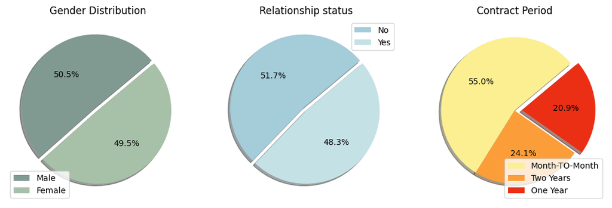

```python
fig, axs = plt.subplots(1,3, figsize=(11, 9))

axs[0].pie(df['gender'].value_counts(), colors=['#819A91', '#A7C1A8'], startangle=40, explode=[0.05, 0], shadow=True, autopct='%1.1f%%')
axs[0].legend(labels=['Male', 'Female'])
axs[0].set_title('Gender Distribution')

axs[1].pie(df['Partner'].value_counts(), colors=['#A4CCD9', '#C4E1E6'], startangle=40, explode=[0.05, 0], shadow=True, autopct='%1.1f%%')
axs[1].legend(labels=['No', 'Yes'])
axs[1].set_title('Relationship status')

axs[2].pie(df['Contract'].value_counts(), colors=['#FCEF91', '#FB9E3A', '#EA2F14'], startangle=40, explode=[0, 0, 0.1], shadow=True, autopct='%1.1f%%')
axs[2].legend(labels=['Month-TO-Month', 'Two Years', 'One Year'])
axs[2].set_title('Contract Period')

plt.tight_layout(pad=3)
plt.show()
```

```python
import seaborn as sns
```

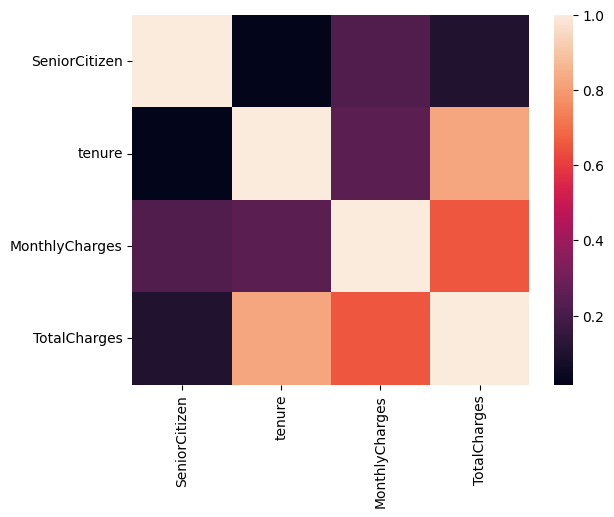

```python
sns.heatmap(df.corr(numeric_only=True))
plt.show()
```

```python
df.isnull().sum()
```

```
gender               0
SeniorCitizen        0
Partner              0
Dependents           0
tenure               0
PhoneService         0
MultipleLines        0
InternetService      0
OnlineSecurity       0
OnlineBackup         0
DeviceProtection     0
TechSupport          0
StreamingTV          0
StreamingMovies      0
Contract             0
PaperlessBilling     0
PaymentMethod        0
MonthlyCharges       0
TotalCharges        11
Churn                0
dtype: int64
```

## 🧼 Data Preprocessing & Encoding

To prepare the dataset:

- Categorical columns are encoded using **BinaryEncoder** and **TargetEncoder**
- Numerical values are scaled using **StandardScaler**
- Missing values are handled appropriately

These transformations are essential for ML models to understand the data effectively.

```python
from category_encoders import BinaryEncoder, TargetEncoder
```

```python
be = BinaryEncoder(handle_missing='value', handle_unknown='value', drop_invariant=False)
```

```python
te = TargetEncoder()
```

```python
from sklearn.preprocessing import OneHotEncoder, StandardScaler
```

```python
ohe = OneHotEncoder(handle_unknown='ignore', sparse_output=False)
```

```python
ss = StandardScaler()
```

```python
from sklearn.impute import SimpleImputer
```

```python
simple = SimpleImputer(strategy='mean')
```

```python
df['TotalCharges'] = simple.fit_transform(df[['TotalCharges']])
```

```python
categorical_cols = []
num_cols = []
bin_num_col = []

not_col = ['customerID', 'Churn']

for category in df.columns :
    if category not in not_col :
        if df[category].dtype == 'object':
            if df[category].nunique() == 2 :
                bin_num_col.append(category)
            else :
                categorical_cols.append(category)
        else :
            num_cols.append(category)

print('------------Categorical columns: \n', categorical_cols, '\n\n')
print('-----------------Numeric columns for standard scale: \n', num_cols)
print('-----------------categorical columns for Binary encoding: \n', bin_num_col)
```

```
------------Categorical columns:
 ['MultipleLines', 'InternetService', 'OnlineSecurity', 'OnlineBackup', 'DeviceProtection', 'TechSupport', 'StreamingTV', 'StreamingMovies', 'Contract', 'PaymentMethod']


-----------------Numeric columns for standard scale:
 ['SeniorCitizen', 'tenure', 'MonthlyCharges', 'TotalCharges']
-----------------categorical columns for Binary encoding:
 ['gender', 'Partner', 'Dependents', 'PhoneService', 'PaperlessBilling']
```

## 🔗 Feature Relationships: Pairplot

Let’s visualize the relationships between some key features using `seaborn.pairplot()`. This helps us understand:

- Which features are correlated
- How churn (target variable) separates clusters

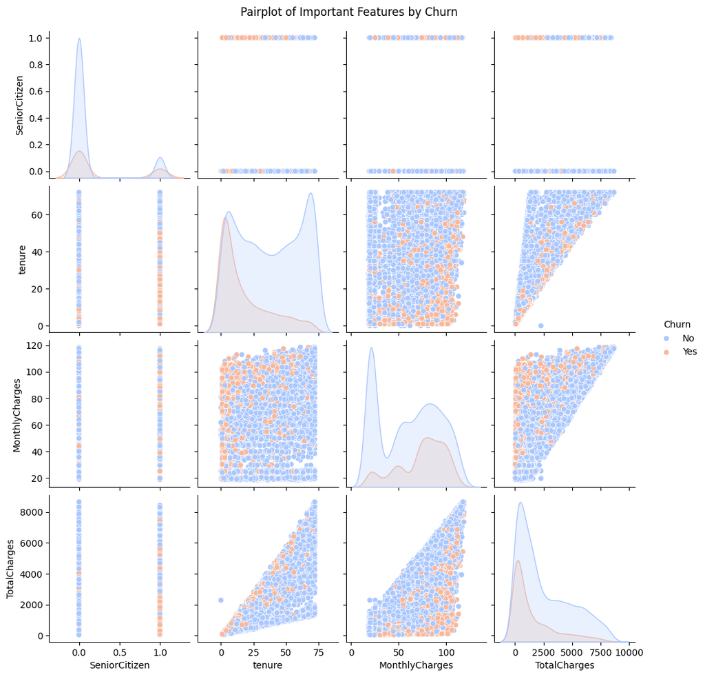

```python
num_cols.append('Churn')

sns.pairplot(df[num_cols], hue="Churn", palette='coolwarm')
plt.suptitle("Pairplot of Important Features by Churn", y=1.02)
plt.show()

num_cols.remove('Churn')
```

```python
from sklearn.compose import make_column_transformer
```

```python
transform = make_column_transformer(
    (be, bin_num_col),
    (ss, num_cols)
)
```

```python
from sklearn.ensemble import RandomForestClassifier
```

```python
rfc = RandomForestClassifier(random_state=42)
```

```python
X = df.drop(columns={'Churn'})
```

```python
df['Churn'] = df['Churn'].replace({'Yes': 1, 'No': 0})
df['Churn'] = df['Churn'].astype(int)
y = df['Churn']
```

## ✂️ Train-Test Split

```python
from sklearn.model_selection import train_test_split
```

```python
X_train, X_test, y_train, y_test = train_test_split(X, y, random_state=42, test_size=0.3)
```

```python
X_train_te = X_train.copy()
X_test_te = X_test.copy()

X_train_te[categorical_cols] = te.fit_transform(X_train[categorical_cols], y_train)
X_test_te[categorical_cols] = te.transform(X_test[categorical_cols])
```

[output not shown]

[output cut: 295 more lines]

[output not shown]

## ⚖️ Balancing Classes using SMOTE

Churn prediction is an imbalanced classification problem. We use **SMOTE (Synthetic Minority Over-sampling Technique)** to oversample the minority class in the training data.

```python
from imblearn.over_sampling import SMOTE
```

```python
smt = SMOTE(random_state=42)
```

```python
from imblearn.pipeline import Pipeline
```

```python
pipe = Pipeline([
    ('preprocessor', transform),
    ('smote', smt),
    ('classifier', rfc)
])
```

```python
pipe.fit(X_train_te, y_train)
```

[output not shown]

[output cut: 50 more lines]

[output not shown]

```
Pipeline(steps=[('preprocessor',
                 ColumnTransformer(transformers=[('binaryencoder',
                                                  BinaryEncoder(),
                                                  ['gender', 'Partner',
                                                   'Dependents', 'PhoneService',
                                                   'PaperlessBilling']),
                                                 ('standardscaler',
                                                  StandardScaler(),
                                                  ['SeniorCitizen', 'tenure',
                                                   'MonthlyCharges',
                                                   'TotalCharges'])])),
                ('smote', SMOTE(random_state=42)),
                ('classifier', RandomForestClassifier(random_state=42))])
```

```python
from sklearn.metrics import classification_report, confusion_matrix
```

```python
pre_1 = pipe.predict(X_test_te)
```

[output not shown]

```python
cm_1 = confusion_matrix(y_test, pre_1)
```

```python
cr_1 = classification_report(y_test, pre_1)
```

```python
print(cm_1)
```

```
[[1227  312]
 [ 240  334]]
```

```python
print(cr_1)
```

```
              precision    recall  f1-score   support

           0       0.84      0.80      0.82      1539
           1       0.52      0.58      0.55       574

    accuracy                           0.74      2113
   macro avg       0.68      0.69      0.68      2113
weighted avg       0.75      0.74      0.74      2113
```

```python
X_train_te_new = X_train_te.copy()
X_test_te_new = X_test_te.copy()

bin_encoded_train = be.fit_transform(X_train_te_new[bin_num_col])
bin_encoded_test = be.transform(X_test_te_new[bin_num_col])

# Converting to DataFrame and set proper column names
bin_encoded_train_df = pd.DataFrame(bin_encoded_train, columns=be.get_feature_names_out(bin_num_col), index=X_train_te_new.index)
bin_encoded_test_df = pd.DataFrame(bin_encoded_test, columns=be.get_feature_names_out(bin_num_col), index=X_test_te_new.index)

# Droping original binary columns
X_train_te_new.drop(columns=bin_num_col, inplace=True)
X_test_te_new.drop(columns=bin_num_col, inplace=True)

# Concatenate column's
X_train_te_new = pd.concat([X_train_te_new, bin_encoded_train_df], axis=1)
X_test_te_new = pd.concat([X_test_te_new, bin_encoded_test_df], axis=1)
```

[output not shown]

[output cut: 85 more lines]

[output not shown]

```python
X_train_te_new[num_cols] = ss.fit_transform(X_train_te_new[num_cols])
X_train_te_new[num_cols] = ss.fit_transform(X_train_te_new[num_cols])
```

```python
smote_X_train, smote_y_train = smt.fit_resample(X_train_te_new, y_train)
smote_X_test, smote_y_test = smt.fit_resample(X_test_te_new, y_test)
```

## 🎯 Hyperparameter Tuning using Optuna

Optuna is used to fine-tune model hyperparameters efficiently. This helps improve accuracy and generalization by searching the optimal parameter space.

```python
import optuna
```

```python
from sklearn.model_selection import GridSearchCV, StratifiedKFold, cross_val_score
```

```python
from xgboost import XGBClassifier
```

```python
from lightgbm import LGBMClassifier
```

```python
from sklearn.ensemble import VotingClassifier
```

```python
from sklearn.linear_model import LogisticRegression
```

```python
def objective(trial):
    # Random Forest
    rf_n_estimators = trial.suggest_int('rf_n_estimators', 100, 500, step=50)
    rf_max_depth = trial.suggest_int('rf_max_depth', 3, 20)

    clf_rf = RandomForestClassifier(
        n_estimators=rf_n_estimators,
        max_depth=rf_max_depth,
        random_state=42,
        n_jobs=-1
    )

    # XGBoost
    xgb_n_estimators = trial.suggest_int('xgb_n_estimators', 100, 500, step=50)
    xgb_learning_rate = trial.suggest_float('xgb_learning_rate', 0.01, 0.3, log=True)
    xgb_max_depth = trial.suggest_int('xgb_max_depth', 3, 20)
    xgb_subsample = trial.suggest_float('xgb_subsample', 0.5, 1.0)
    xgb_colsample_bytree = trial.suggest_float('xgb_colsample_bytree', 0.5, 1.0)
    xgb_gamma = trial.suggest_float('xgb_gamma', 0, 5)
    xgb_reg_lambda = trial.suggest_float('xgb_reg_lambda', 0.0, 5.0)
    xgb_reg_alpha = trial.suggest_float('xgb_reg_alpha', 0.0, 5.0)
    xgb_scale_pos_weight = trial.suggest_float('xgb_scale_pos_weight', 1.0, 10.0)

    clf_xgb = XGBClassifier(
        n_estimators=xgb_n_estimators,
        learning_rate=xgb_learning_rate,
        max_depth=xgb_max_depth,
        subsample=xgb_subsample,
        colsample_bytree=xgb_colsample_bytree,
        gamma=xgb_gamma,
        reg_lambda=xgb_reg_lambda,
        reg_alpha=xgb_reg_alpha,
        scale_pos_weight=xgb_scale_pos_weight,
        use_label_encoder=False,
        eval_metric='logloss',
        random_state=42,
        n_jobs=-1
    )

    # LightGBM
    lgb_n_estimators = trial.suggest_int('lgb_n_estimators', 100, 500, step=50)
    lgb_learning_rate = trial.suggest_float('lgb_learning_rate', 0.01, 0.3, log=True)
    lgb_max_depth = trial.suggest_int('lgb_max_depth', 3, 20)
    lgb_num_leaves = trial.suggest_int('lgb_num_leaves', 15, 150, step=5)
    lgb_min_child_samples = trial.suggest_int('lgb_min_child_samples', 10, 100, step=10)

    clf_lgb = LGBMClassifier(
        n_estimators=lgb_n_estimators,
        learning_rate=lgb_learning_rate,
        max_depth=lgb_max_depth,
        num_leaves=lgb_num_leaves,
        min_child_samples=lgb_min_child_samples,
        random_state=42,
        n_jobs=-1
    )

    # Logistic Regression
    lr_C = trial.suggest_float('lr_C', 0.001, 10.0, log=True)
    lr_penalty = trial.suggest_categorical('lr_penalty', ['l2'])
    lr_solver = trial.suggest_categorical('lr_solver', ['liblinear', 'lbfgs'])


    clf_lr = LogisticRegression(
        C=lr_C,
        penalty=lr_penalty,
        solver=lr_solver,
        random_state=42,
        max_iter=1000
    )

    # Combining multiple classifiers for best result
    voting = VotingClassifier(
        estimators=[
            ('rf', clf_rf),
            ('xgb', clf_xgb),
            ('lgb', clf_lgb),
            ('lr', clf_lr),
        ],
        voting='soft',
        n_jobs=-1
    )

    # Cross-validation score
    skf = StratifiedKFold(n_splits=3, shuffle=True, random_state=42)
    score = cross_val_score(voting, smote_X_train, smote_y_train, cv=skf, scoring='f1', n_jobs=1)

    if trial.should_prune() :
        raise optuna.TrialPruned()

    return score.mean()
```

```python
pruner = optuna.pruners.MedianPruner(n_startup_trials=5, n_warmup_steps=1)
study = optuna.create_study(direction='maximize', pruner=pruner)
study.optimize(objective, n_trials=50, show_progress_bar=True)
```

```
[I 2025-07-09 08:57:07,706] A new study created in memory with name: no-name-65237200-5c9b-45f9-a668-87a95f55d7f3
```

```
[I 2025-07-09 08:57:26,142] Trial 0 finished with value: 0.8402467621554418 and parameters: {'rf_n_estimators': 450, 'rf_max_depth': 8, 'xgb_n_estimators': 450, 'xgb_learning_rate': 0.10475719283221296, 'xgb_max_depth': 19, 'xgb_subsample': 0.73837279749728, 'xgb_colsample_bytree': 0.874920883861580…
```

```
[I 2025-07-09 08:57:40,593] Trial 1 finished with value: 0.8493213237343101 and parameters: {'rf_n_estimators': 200, 'rf_max_depth': 15, 'xgb_n_estimators': 500, 'xgb_learning_rate': 0.11768827065470439, 'xgb_max_depth': 8, 'xgb_subsample': 0.5250891098821309, 'xgb_colsample_bytree': 0.6096164843589…
```

```
[I 2025-07-09 08:57:52,282] Trial 2 finished with value: 0.8527277328189133 and parameters: {'rf_n_estimators': 200, 'rf_max_depth': 19, 'xgb_n_estimators': 450, 'xgb_learning_rate': 0.2659706863575002, 'xgb_max_depth': 12, 'xgb_subsample': 0.9219555104381909, 'xgb_colsample_bytree': 0.7387411877168…
```

```
[I 2025-07-09 08:58:09,494] Trial 3 finished with value: 0.8418571562047319 and parameters: {'rf_n_estimators': 500, 'rf_max_depth': 9, 'xgb_n_estimators': 200, 'xgb_learning_rate': 0.03552199216476804, 'xgb_max_depth': 8, 'xgb_subsample': 0.7063123956935555, 'xgb_colsample_bytree': 0.78334099364307…
```

```
[I 2025-07-09 08:58:19,848] Trial 4 finished with value: 0.8435842595182091 and parameters: {'rf_n_estimators': 500, 'rf_max_depth': 6, 'xgb_n_estimators': 100, 'xgb_learning_rate': 0.152502305209646, 'xgb_max_depth': 11, 'xgb_subsample': 0.6494209591338693, 'xgb_colsample_bytree': 0.927846740951583…
```

```
[I 2025-07-09 08:59:02,116] Trial 5 finished with value: 0.8519875250383606 and parameters: {'rf_n_estimators': 500, 'rf_max_depth': 18, 'xgb_n_estimators': 300, 'xgb_learning_rate': 0.16108089551005597, 'xgb_max_depth': 14, 'xgb_subsample': 0.6729580359370405, 'xgb_colsample_bytree': 0.562700630582…
```

```
[I 2025-07-09 08:59:39,482] Trial 6 finished with value: 0.8513588745464621 and parameters: {'rf_n_estimators': 300, 'rf_max_depth': 18, 'xgb_n_estimators': 100, 'xgb_learning_rate': 0.03110505483686602, 'xgb_max_depth': 17, 'xgb_subsample': 0.8084433316768156, 'xgb_colsample_bytree': 0.668552970482…
```

```
[I 2025-07-09 08:59:50,849] Trial 7 finished with value: 0.8294593394798909 and parameters: {'rf_n_estimators': 350, 'rf_max_depth': 6, 'xgb_n_estimators': 100, 'xgb_learning_rate': 0.014697262079023573, 'xgb_max_depth': 9, 'xgb_subsample': 0.7749246205248602, 'xgb_colsample_bytree': 0.7215200390269…
```

```
[I 2025-07-09 08:59:56,849] Trial 8 finished with value: 0.8439955077043398 and parameters: {'rf_n_estimators': 100, 'rf_max_depth': 3, 'xgb_n_estimators': 150, 'xgb_learning_rate': 0.04580393434127951, 'xgb_max_depth': 11, 'xgb_subsample': 0.8708043520048581, 'xgb_colsample_bytree': 0.6123143964649…
```

```
[I 2025-07-09 09:00:25,087] Trial 9 finished with value: 0.8455781841268929 and parameters: {'rf_n_estimators': 450, 'rf_max_depth': 14, 'xgb_n_estimators': 500, 'xgb_learning_rate': 0.07465481349248078, 'xgb_max_depth': 6, 'xgb_subsample': 0.5491482106777231, 'xgb_colsample_bytree': 0.8755290200019…
```

```
[I 2025-07-09 09:01:32,605] Trial 10 finished with value: 0.8515885069257211 and parameters: {'rf_n_estimators': 100, 'rf_max_depth': 20, 'xgb_n_estimators': 400, 'xgb_learning_rate': 0.2515257556321934, 'xgb_max_depth': 4, 'xgb_subsample': 0.9945672461120714, 'xgb_colsample_bytree': 0.7874261534605…
```

```
[I 2025-07-09 09:02:05,322] Trial 11 finished with value: 0.8525758688881689 and parameters: {'rf_n_estimators': 250, 'rf_max_depth': 17, 'xgb_n_estimators': 300, 'xgb_learning_rate': 0.25704217452583156, 'xgb_max_depth': 14, 'xgb_subsample': 0.9469305542593238, 'xgb_colsample_bytree': 0.51734510530…
```

```
[I 2025-07-09 09:02:27,641] Trial 12 finished with value: 0.853580465019757 and parameters: {'rf_n_estimators': 250, 'rf_max_depth': 14, 'xgb_n_estimators': 300, 'xgb_learning_rate': 0.2767781992382716, 'xgb_max_depth': 15, 'xgb_subsample': 0.9779952473867544, 'xgb_colsample_bytree': 0.5293727970893…
```

```
[I 2025-07-09 09:02:49,208] Trial 13 finished with value: 0.8475179520503257 and parameters: {'rf_n_estimators': 200, 'rf_max_depth': 12, 'xgb_n_estimators': 350, 'xgb_learning_rate': 0.23592385014784284, 'xgb_max_depth': 15, 'xgb_subsample': 0.8939010359521505, 'xgb_colsample_bytree': 0.98377141578…
```

```
[I 2025-07-09 09:02:56,655] Trial 14 finished with value: 0.8522649398538235 and parameters: {'rf_n_estimators': 200, 'rf_max_depth': 15, 'xgb_n_estimators': 250, 'xgb_learning_rate': 0.2952871239698476, 'xgb_max_depth': 20, 'xgb_subsample': 0.9977409235762341, 'xgb_colsample_bytree': 0.716756185755…
```

```
[I 2025-07-09 09:03:25,325] Trial 15 finished with value: 0.8529886877519409 and parameters: {'rf_n_estimators': 350, 'rf_max_depth': 20, 'xgb_n_estimators': 400, 'xgb_learning_rate': 0.011074007250857814, 'xgb_max_depth': 16, 'xgb_subsample': 0.8574422606403715, 'xgb_colsample_bytree': 0.6588657085…
```

```
[I 2025-07-09 09:03:54,313] Trial 16 finished with value: 0.8507570240054686 and parameters: {'rf_n_estimators': 350, 'rf_max_depth': 11, 'xgb_n_estimators': 350, 'xgb_learning_rate': 0.01206443044979833, 'xgb_max_depth': 17, 'xgb_subsample': 0.844470628463601, 'xgb_colsample_bytree': 0.508183536191…
```

```
[I 2025-07-09 09:04:17,774] Trial 17 finished with value: 0.851205066988658 and parameters: {'rf_n_estimators': 350, 'rf_max_depth': 13, 'xgb_n_estimators': 350, 'xgb_learning_rate': 0.01888701976122391, 'xgb_max_depth': 17, 'xgb_subsample': 0.9471703431091187, 'xgb_colsample_bytree': 0.646262333980…
```

```
[I 2025-07-09 09:04:39,780] Trial 18 finished with value: 0.8493107129960222 and parameters: {'rf_n_estimators': 300, 'rf_max_depth': 16, 'xgb_n_estimators': 250, 'xgb_learning_rate': 0.027048892382104475, 'xgb_max_depth': 15, 'xgb_subsample': 0.8398825737681984, 'xgb_colsample_bytree': 0.5703965674…
```

```
[I 2025-07-09 09:05:07,892] Trial 19 finished with value: 0.8518323508092802 and parameters: {'rf_n_estimators': 400, 'rf_max_depth': 20, 'xgb_n_estimators': 400, 'xgb_learning_rate': 0.06711205874345175, 'xgb_max_depth': 13, 'xgb_subsample': 0.7884184479862687, 'xgb_colsample_bytree': 0.67075196427…
```

```
[I 2025-07-09 09:05:40,006] Trial 20 finished with value: 0.846852698170292 and parameters: {'rf_n_estimators': 250, 'rf_max_depth': 10, 'xgb_n_estimators': 250, 'xgb_learning_rate': 0.01028011400433434, 'xgb_max_depth': 19, 'xgb_subsample': 0.9039531164950869, 'xgb_colsample_bytree': 0.559082380542…
```

```
[I 2025-07-09 09:05:51,906] Trial 21 finished with value: 0.85022755698705 and parameters: {'rf_n_estimators': 150, 'rf_max_depth': 19, 'xgb_n_estimators': 450, 'xgb_learning_rate': 0.18357010320238185, 'xgb_max_depth': 12, 'xgb_subsample': 0.9379888690267117, 'xgb_colsample_bytree': 0.7565757665038…
```

```
[I 2025-07-09 09:06:05,675] Trial 22 finished with value: 0.8536133441507417 and parameters: {'rf_n_estimators': 250, 'rf_max_depth': 17, 'xgb_n_estimators': 400, 'xgb_learning_rate': 0.09769918563916781, 'xgb_max_depth': 16, 'xgb_subsample': 0.9114719245967715, 'xgb_colsample_bytree': 0.81050144191…
```

```
[I 2025-07-09 09:06:27,819] Trial 23 finished with value: 0.853580611128236 and parameters: {'rf_n_estimators': 300, 'rf_max_depth': 17, 'xgb_n_estimators': 400, 'xgb_learning_rate': 0.08059299682651644, 'xgb_max_depth': 16, 'xgb_subsample': 0.9709100652723391, 'xgb_colsample_bytree': 0.848471953681…
```

```
[I 2025-07-09 09:06:42,480] Trial 24 finished with value: 0.8546856630546736 and parameters: {'rf_n_estimators': 250, 'rf_max_depth': 16, 'xgb_n_estimators': 350, 'xgb_learning_rate': 0.08977417796298959, 'xgb_max_depth': 16, 'xgb_subsample': 0.9742341141526573, 'xgb_colsample_bytree': 0.83199272127…
```

```
[I 2025-07-09 09:06:56,936] Trial 25 finished with value: 0.8499807142035744 and parameters: {'rf_n_estimators': 300, 'rf_max_depth': 17, 'xgb_n_estimators': 400, 'xgb_learning_rate': 0.09269744585041592, 'xgb_max_depth': 18, 'xgb_subsample': 0.9678991387208292, 'xgb_colsample_bytree': 0.85227860937…
```

```
[I 2025-07-09 09:07:08,359] Trial 26 finished with value: 0.854546065199033 and parameters: {'rf_n_estimators': 250, 'rf_max_depth': 16, 'xgb_n_estimators': 350, 'xgb_learning_rate': 0.05879599166823785, 'xgb_max_depth': 20, 'xgb_subsample': 0.9048336695877964, 'xgb_colsample_bytree': 0.824609014794…
```

```
[I 2025-07-09 09:07:15,640] Trial 27 finished with value: 0.849952835173187 and parameters: {'rf_n_estimators': 150, 'rf_max_depth': 15, 'xgb_n_estimators': 350, 'xgb_learning_rate': 0.05681574105304834, 'xgb_max_depth': 20, 'xgb_subsample': 0.8928063626210194, 'xgb_colsample_bytree': 0.808904652243…
```

```
[I 2025-07-09 09:07:27,509] Trial 28 finished with value: 0.8480795733392115 and parameters: {'rf_n_estimators': 250, 'rf_max_depth': 16, 'xgb_n_estimators': 300, 'xgb_learning_rate': 0.048956966086802146, 'xgb_max_depth': 18, 'xgb_subsample': 0.8248068209940568, 'xgb_colsample_bytree': 0.9320230626…
```

```
[I 2025-07-09 09:07:35,000] Trial 29 finished with value: 0.8501493702339115 and parameters: {'rf_n_estimators': 150, 'rf_max_depth': 13, 'xgb_n_estimators': 450, 'xgb_learning_rate': 0.10724400002529347, 'xgb_max_depth': 19, 'xgb_subsample': 0.7328803407439297, 'xgb_colsample_bytree': 0.90650231434…
```

```
[I 2025-07-09 09:07:43,887] Trial 30 finished with value: 0.8530582507464919 and parameters: {'rf_n_estimators': 250, 'rf_max_depth': 13, 'xgb_n_estimators': 350, 'xgb_learning_rate': 0.12928925116837822, 'xgb_max_depth': 20, 'xgb_subsample': 0.8712821921812502, 'xgb_colsample_bytree': 0.82242541703…
```

```
[I 2025-07-09 09:08:06,357] Trial 31 finished with value: 0.8523276494442019 and parameters: {'rf_n_estimators': 300, 'rf_max_depth': 17, 'xgb_n_estimators': 400, 'xgb_learning_rate': 0.08537928300500462, 'xgb_max_depth': 16, 'xgb_subsample': 0.9220366611517915, 'xgb_colsample_bytree': 0.86134281697…
```

```
[I 2025-07-09 09:08:21,143] Trial 32 finished with value: 0.8511657542770839 and parameters: {'rf_n_estimators': 300, 'rf_max_depth': 16, 'xgb_n_estimators': 450, 'xgb_learning_rate': 0.06339870303065244, 'xgb_max_depth': 18, 'xgb_subsample': 0.9591711830005628, 'xgb_colsample_bytree': 0.83292660117…
```

```
[I 2025-07-09 09:08:34,366] Trial 33 finished with value: 0.8530625224915206 and parameters: {'rf_n_estimators': 200, 'rf_max_depth': 18, 'xgb_n_estimators': 400, 'xgb_learning_rate': 0.08040321686880748, 'xgb_max_depth': 16, 'xgb_subsample': 0.9163308902497813, 'xgb_colsample_bytree': 0.89076990595…
```

```
[I 2025-07-09 09:08:50,178] Trial 34 finished with value: 0.8532848787659167 and parameters: {'rf_n_estimators': 250, 'rf_max_depth': 15, 'xgb_n_estimators': 500, 'xgb_learning_rate': 0.12242717171217952, 'xgb_max_depth': 13, 'xgb_subsample': 0.9974594085866706, 'xgb_colsample_bytree': 0.77356844400…
```

```
[I 2025-07-09 09:09:06,355] Trial 35 finished with value: 0.8560323036004464 and parameters: {'rf_n_estimators': 400, 'rf_max_depth': 18, 'xgb_n_estimators': 350, 'xgb_learning_rate': 0.03683389391307167, 'xgb_max_depth': 10, 'xgb_subsample': 0.5965563164173388, 'xgb_colsample_bytree': 0.96473836834…
```

```
[I 2025-07-09 09:09:22,253] Trial 36 finished with value: 0.856717391856007 and parameters: {'rf_n_estimators': 400, 'rf_max_depth': 19, 'xgb_n_estimators': 350, 'xgb_learning_rate': 0.03935156740666243, 'xgb_max_depth': 9, 'xgb_subsample': 0.5855517187003545, 'xgb_colsample_bytree': 0.9676451844957…
```

```
[I 2025-07-09 09:09:37,553] Trial 37 finished with value: 0.8548103169459944 and parameters: {'rf_n_estimators': 400, 'rf_max_depth': 19, 'xgb_n_estimators': 350, 'xgb_learning_rate': 0.03733929398170347, 'xgb_max_depth': 9, 'xgb_subsample': 0.5870630910020599, 'xgb_colsample_bytree': 0.985794072225…
```

```
[I 2025-07-09 09:09:54,639] Trial 38 finished with value: 0.8550827797165645 and parameters: {'rf_n_estimators': 450, 'rf_max_depth': 19, 'xgb_n_estimators': 250, 'xgb_learning_rate': 0.0399169445071519, 'xgb_max_depth': 9, 'xgb_subsample': 0.5868883421138508, 'xgb_colsample_bytree': 0.9964188061642…
```

```
[I 2025-07-09 09:10:11,385] Trial 39 finished with value: 0.8538759268299035 and parameters: {'rf_n_estimators': 450, 'rf_max_depth': 19, 'xgb_n_estimators': 200, 'xgb_learning_rate': 0.03856591278935909, 'xgb_max_depth': 9, 'xgb_subsample': 0.5870900464655332, 'xgb_colsample_bytree': 0.995689452356…
```

```
[I 2025-07-09 09:10:26,628] Trial 40 finished with value: 0.8509417995626659 and parameters: {'rf_n_estimators': 400, 'rf_max_depth': 19, 'xgb_n_estimators': 200, 'xgb_learning_rate': 0.025468180216568354, 'xgb_max_depth': 7, 'xgb_subsample': 0.6224149497699608, 'xgb_colsample_bytree': 0.94547390354…
```

```
[I 2025-07-09 09:10:41,933] Trial 41 finished with value: 0.8566326599148576 and parameters: {'rf_n_estimators': 400, 'rf_max_depth': 19, 'xgb_n_estimators': 300, 'xgb_learning_rate': 0.038205643327176186, 'xgb_max_depth': 10, 'xgb_subsample': 0.5059812181324528, 'xgb_colsample_bytree': 0.9657062044…
```

```
[I 2025-07-09 09:10:57,492] Trial 42 finished with value: 0.8548440267522078 and parameters: {'rf_n_estimators': 400, 'rf_max_depth': 19, 'xgb_n_estimators': 300, 'xgb_learning_rate': 0.036692921522027855, 'xgb_max_depth': 10, 'xgb_subsample': 0.5064337545528106, 'xgb_colsample_bytree': 0.9634985958…
```

```
[I 2025-07-09 09:11:14,661] Trial 43 finished with value: 0.8554608120222561 and parameters: {'rf_n_estimators': 450, 'rf_max_depth': 18, 'xgb_n_estimators': 250, 'xgb_learning_rate': 0.02069684469268363, 'xgb_max_depth': 10, 'xgb_subsample': 0.5026130110756011, 'xgb_colsample_bytree': 0.96188411548…
```

```
[I 2025-07-09 09:11:33,694] Trial 44 finished with value: 0.8542576401569612 and parameters: {'rf_n_estimators': 500, 'rf_max_depth': 18, 'xgb_n_estimators': 250, 'xgb_learning_rate': 0.01927834626279699, 'xgb_max_depth': 10, 'xgb_subsample': 0.5484139828338224, 'xgb_colsample_bytree': 0.95844450611…
```

```
[I 2025-07-09 09:11:50,615] Trial 45 finished with value: 0.848730751577503 and parameters: {'rf_n_estimators': 450, 'rf_max_depth': 20, 'xgb_n_estimators': 200, 'xgb_learning_rate': 0.029633676695360957, 'xgb_max_depth': 6, 'xgb_subsample': 0.5424773824863086, 'xgb_colsample_bytree': 0.910723069396…
```

```
[I 2025-07-09 09:12:07,521] Trial 46 finished with value: 0.8503690856804346 and parameters: {'rf_n_estimators': 450, 'rf_max_depth': 18, 'xgb_n_estimators': 300, 'xgb_learning_rate': 0.02245294320741282, 'xgb_max_depth': 8, 'xgb_subsample': 0.580096998767192, 'xgb_colsample_bytree': 0.9667057230075…
```

```
[I 2025-07-09 09:12:19,042] Trial 47 finished with value: 0.8543783240854799 and parameters: {'rf_n_estimators': 450, 'rf_max_depth': 8, 'xgb_n_estimators': 150, 'xgb_learning_rate': 0.043905763982897125, 'xgb_max_depth': 10, 'xgb_subsample': 0.6740707585100175, 'xgb_colsample_bytree': 0.92533111772…
```

```
[I 2025-07-09 09:12:29,805] Trial 48 finished with value: 0.8446273315489222 and parameters: {'rf_n_estimators': 500, 'rf_max_depth': 4, 'xgb_n_estimators': 250, 'xgb_learning_rate': 0.03147180773408792, 'xgb_max_depth': 7, 'xgb_subsample': 0.5074996671305336, 'xgb_colsample_bytree': 0.9725477608700…
```

```
[I 2025-07-09 09:12:44,720] Trial 49 finished with value: 0.8495918521438032 and parameters: {'rf_n_estimators': 400, 'rf_max_depth': 18, 'xgb_n_estimators': 150, 'xgb_learning_rate': 0.01587603371294562, 'xgb_max_depth': 11, 'xgb_subsample': 0.6249962508988056, 'xgb_colsample_bytree': 0.94286249266…
```

```python
print("Best params: ", study.best_params)
print("Best value: ", study.best_value)
```

```
Best params:  {'rf_n_estimators': 400, 'rf_max_depth': 19, 'xgb_n_estimators': 350, 'xgb_learning_rate': 0.03935156740666243, 'xgb_max_depth': 9, 'xgb_subsample': 0.5855517187003545, 'xgb_colsample_bytree': 0.9676451844957327, 'xgb_gamma': 1.1603362451363395, 'xgb_reg_lambda': 4.278685131045036, 'xg…
Best value:  0.856717391856007
```

```python
rfc = RandomForestClassifier(
    n_estimators=100,
    max_depth=17,
    random_state=42,
    n_jobs=-1
)

xgb = XGBClassifier(
    n_estimators=100,
    learning_rate=0.05711522509359269,
    max_depth=20,
    subsample=0.8400305135748165,
    colsample_bytree=0.5058880268128743,
    gamma=2.893128125227293,
    reg_lambda=2.316076702593192,
    reg_alpha=1.2857080854092322,
    scale_pos_weight=1.004982817889463,
    use_label_encoder=False,
    eval_metric='logloss',
    random_state=42,
    n_jobs=-1
)

lgbm = LGBMClassifier(
    n_estimators=300,
    learning_rate=0.04042560235052731,
    max_depth=12,
    num_leaves=60,
    min_child_samples=30,
    random_state=42,
    n_jobs=-1
)

lr = LogisticRegression(
    C=0.012664730646344463,
    penalty='l2',
    solver='lbfgs',
    random_state=42
)

# Voting classifier (soft voting gives better probability-based results)
voting_clf = VotingClassifier(
    estimators=[
        ('rf', rfc),
        ('xgb', xgb),
        ('lgb', lgbm),
        ('lr', lr)
    ],
    voting='soft',
    n_jobs=-1
)
```

```python
voting_clf.fit(smote_X_train, smote_y_train)
```

```
VotingClassifier(estimators=[('rf',
                              RandomForestClassifier(max_depth=17, n_jobs=-1,
                                                     random_state=42)),
                             ('xgb',
                              XGBClassifier(base_score=None, booster=None,
                                            callbacks=None,
                                            colsample_bylevel=None,
                                            colsample_bynode=None,
                                            colsample_bytree=0.5058880268128743,
                                            device=None,
                                            early_stopping_rounds=None,
                                            enable_categorical=False,
                                            eval_metric='logloss',
                                            feature_types=None,...
                                            min_child_weight=None, missing=nan,
                                            monotone_constraints=None,
                                            multi_strategy=None,
                                            n_estimators=100, n_jobs=-1,
                                            num_parallel_tree=None, ...)),
                             ('lgb',
                              LGBMClassifier(learning_rate=0.04042560235052731,
                                             max_depth=12, min_child_samples=30,
                                             n_estimators=300, n_jobs=-1,
                                             num_leaves=60, random_state=42)),
                             ('lr',
                              LogisticRegression(C=0.012664730646344463,
                                                 random_state=42))],
                 n_jobs=-1, voting='soft')
```

```python
pre_2 = voting_clf.predict(smote_X_test)
```

```python
cm_2 = confusion_matrix(smote_y_test, pre_2)
cr_2 = classification_report(smote_y_test, pre_2)
```

```python
print(cm_2)
```

```
[[1504   35]
 [ 531 1008]]
```

```python
print(cr_2)
```

```
              precision    recall  f1-score   support

           0       0.74      0.98      0.84      1539
           1       0.97      0.65      0.78      1539

    accuracy                           0.82      3078
   macro avg       0.85      0.82      0.81      3078
weighted avg       0.85      0.82      0.81      3078
```

```python
rfc_smf = RandomForestClassifier(random_state = 42)
```

```python
rfc_smf.fit(smote_X_train, smote_y_train)
```

```
RandomForestClassifier(random_state=42)
```

## 🧠 Feature Selection with SelectFromModel

```python
from sklearn.feature_selection import SelectFromModel
```

```python
sfm = SelectFromModel(rfc_smf, threshold='median')
```

```python
sfm.fit(smote_X_train, smote_y_train)
```

```
SelectFromModel(estimator=RandomForestClassifier(random_state=42),
                threshold='median')
```

```python
# Step 1: Get selected features mask
selected_mask = sfm.get_support()

# Step 2: Use it to fetch actual column names from original DataFrame
selected_features = smote_X_train.columns[selected_mask]

# Step 3: Transform data
X_train_new_arr = sfm.transform(smote_X_train)
X_test_new_arr = sfm.transform(smote_X_test)

# Step 4: Wrap with DataFrame
X_train_new = pd.DataFrame(X_train_new_arr, columns=selected_features, index=smote_X_train.index)
X_test_new = pd.DataFrame(X_test_new_arr, columns=selected_features, index=smote_X_test.index)
```

```python
print(selected_features)
```

```
Index(['tenure', 'MultipleLines', 'InternetService', 'OnlineSecurity',
       'OnlineBackup', 'DeviceProtection', 'TechSupport', 'StreamingTV',
       'Contract', 'PaymentMethod', 'MonthlyCharges', 'TotalCharges'],
      dtype='object')
```

```python
final_pipe = Pipeline([
    ('voting', voting_clf)
])
```

```python
final_pipe.fit(X_train_new, smote_y_train)
```

```
Pipeline(steps=[('voting',
                 VotingClassifier(estimators=[('rf',
                                               RandomForestClassifier(max_depth=17,
                                                                      n_jobs=-1,
                                                                      random_state=42)),
                                              ('xgb',
                                               XGBClassifier(base_score=None,
                                                             booster=None,
                                                             callbacks=None,
                                                             colsample_bylevel=None,
                                                             colsample_bynode=None,
                                                             colsample_bytree=0.5058880268128743,
                                                             device=None,
                                                             early_stopping_rounds=None,
                                                             enable_categorical=False,
                                                             eval_metric='lo...
                                                             missing=nan,
                                                             monotone_constraints=None,
                                                             multi_strategy=None,
                                                             n_estimators=100,
                                                             n_jobs=-1,
                                                             num_parallel_tree=None, ...)),
                                              ('lgb',
                                               LGBMClassifier(learning_rate=0.04042560235052731,
                                                              max_depth=12,
                                                              min_child_samples=30,
                                                              n_estimators=300,
                                                              n_jobs=-1,
                                                              num_leaves=60,
                                                              random_state=42)),
                                              ('lr',
                                               LogisticRegression(C=0.012664730646344463,
                                                                  random_state=42))],
                                  n_jobs=-1, voting='soft'))])
```

```python
pre_3 = final_pipe.predict(X_test_new)
```

## 📊 Final Model Evaluation

The final model is evaluated using metrics like:

- Accuracy
- Precision
- Recall
- F1-score

The confusion matrix and classification report offer a detailed view of how well the model performs across both classes (churn and non-churn).

```python
cm_3 = confusion_matrix(smote_y_test, pre_3)
cr_3 = classification_report(smote_y_test, pre_3)
```

```python
print(cm_3)
```

```
[[1485   54]
 [ 506 1033]]
```

```python
print(cr_3)
```

```
              precision    recall  f1-score   support

           0       0.75      0.96      0.84      1539
           1       0.95      0.67      0.79      1539

    accuracy                           0.82      3078
   macro avg       0.85      0.82      0.81      3078
weighted avg       0.85      0.82      0.81      3078
```

```python
import joblib
```

```python
joblib.dump(final_pipe, 'trained_model.pkl')
joblib.dump(te, 'T_encoder.pkl')
joblib.dump(be, 'B_encoder.pkl')
joblib.dump(ss, 'S_scaler.pkl')
joblib.dump(selected_features, 'selected_columns.pkl')
```

```
['selected_columns.pkl']
```